# Ford GoBike System Data Exploration

## Data Overview

> This data set includes information about individual rides made in a bike-sharing system covering the `greater San Francisco Bay` area during **february 2019**.

## Preliminary Wrangling

- **Dropping the NaN records.**
- **Correct all IDs types to objects.**
- **Create Helper functions to help our analysis.**
- **Remove outliers**

## Feature Engineering

> Feature engineering is the process of transforming raw data into features that better represent the underlying problem to the predictive models, resulting in improved model accuracy on unseen data.  
> In our case we use Feature Engineering to Extract additional feature to illustrate data in more appealing way.
> - `days`: This feature identify day of a week the trip takes place. for example: Monday, Tuesday, Wednesday, Thursday, Friday, Saturday, Sunday.
> - `duration_min`: represent the time in minutes the trip takes.
> - `distance_meter`: trip distance in meters.
> - `hour`: hour at which trip started in 12 hours system.

```python
## removeing outliers
df = Interquartile(df,'age')
df = Interquartile(df,'distance_meter')
df = Interquartile(df,'duration_min')
```

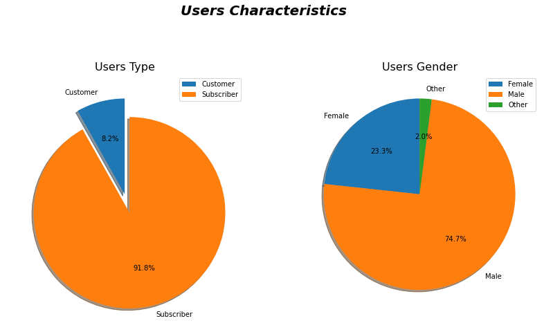

```python
fig = plt.figure(figsize=(14,14))
plt.suptitle('Users Characteristics',fontsize=20,style='italic',fontweight='heavy')
ax = fig.add_subplot(221)
ax.pie(df.groupby('user_type')['user_type'].count(),explode=(0,0.2),
       labels=['Customer','Subscriber'],autopct='%1.1f%%',shadow=True,startangle=90)
plt.title('Users Type',fontsize=16)
plt.legend();

ax = fig.add_subplot(222)
ax.pie(df.groupby('member_gender')['member_gender'].count(),
       labels=['Female','Male','Other'],
       autopct='%1.1f%%',shadow=True,startangle=90)
plt.title('Users Gender',fontsize=16)
plt.legend();
```

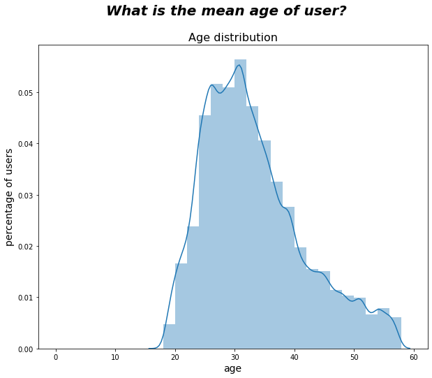

```python
fig = plt.figure(figsize=(10,8))
plt.suptitle('What is the mean age of user?',fontsize=20,style='italic',fontweight='heavy')
bins = np.arange(0,df.age.max()+2,2)
ax = fig.add_subplot(111)
sns.distplot(df.age,bins=bins,ax=ax)
plt.title('Age distribution',fontsize=16)
plt.xlabel('age',fontsize=14)
plt.ylabel('percentage of users',fontsize=14);
```

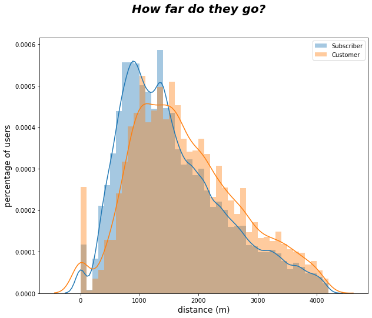

```python
fig = plt.figure(figsize=(10,8))
plt.suptitle('How far do they go?',fontsize= 20,style='italic', fontweight='bold')

distance_meter_subscriber = df.query('user_type == "Subscriber"').distance_meter
distance_meter_customer   = df.query('user_type == "Customer"').distance_meter

bins = np.arange(0,distance_meter_subscriber.max()+100,100)
ax = fig.add_subplot(111)
sns.distplot(distance_meter_subscriber,bins=bins,label='Subscriber',ax=ax)
sns.distplot(distance_meter_customer,bins=bins,label='Customer',ax=ax)
plt.ylabel('percentage of users',fontsize=14)
plt.xlabel('distance (m)',fontsize=14)
plt.legend();
```

**most of users cycle around 1 km for both costumer and subscriber.**

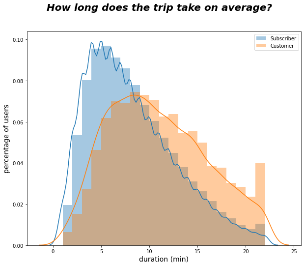

```python
fig = plt.figure(figsize=(10,8))
plt.suptitle('How long does the trip take on average?',fontsize= 20, style='italic',fontweight='bold')

#subscriber or customer
duration_min_subscriber = df.query('user_type == "Subscriber"').duration_min
duration_min_customer = df.query('user_type == "Customer"').duration_min

bins = np.arange(0,duration_min_subscriber.max()+1,1)
ax = fig.add_subplot(111)
sns.distplot(duration_min_subscriber,bins=bins,label='Subscriber',ax=ax)
sns.distplot(duration_min_customer,bins=bins,label='Customer',ax=ax)
plt.xlabel('duration (min)',fontsize=14)
plt.ylabel('percentage of users',fontsize=14)
plt.legend();
```

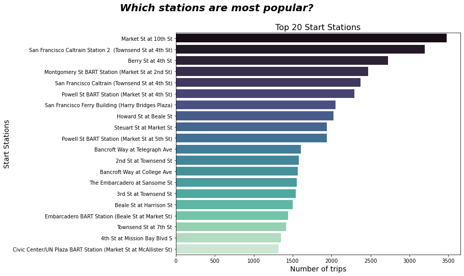

```python
fig = plt.figure(figsize=(10,8))
plt.suptitle('Which stations are most popular?',ha='right',fontsize=20,style='italic',fontweight='heavy')

top_20_start_station = df.start_station_name.value_counts().head(20)
start = top_20_start_station.index
ax = fig.add_subplot(111)
sns.barplot(x=top_20_start_station.values,y=top_20_start_station.index,palette='mako',ax=ax)
plt.title('Top 20 Start Stations',fontsize=16)
plt.xlabel('Number of trips',fontsize=14)
plt.ylabel('Start Stations',fontsize=14);
```

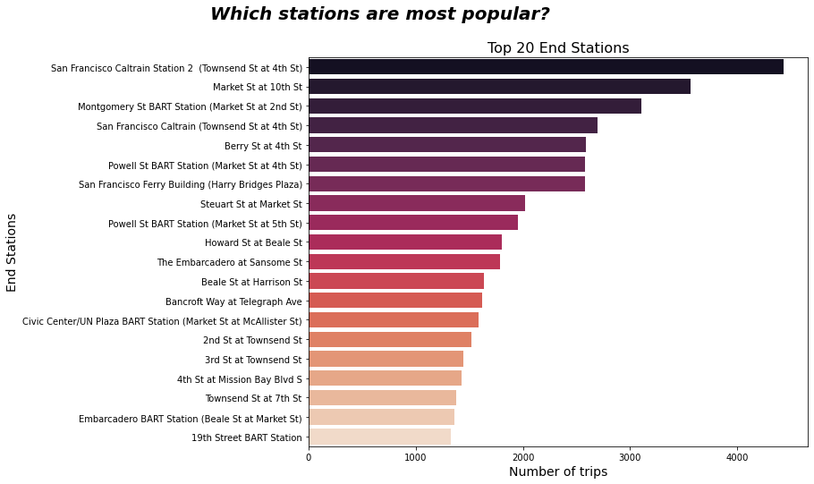

```python
fig = plt.figure(figsize=(10,8))
plt.suptitle('Which stations are most popular?',ha='right',fontsize=20,style='italic',fontweight='heavy')

top_20_end_station = df.end_station_name.value_counts().head(20)
end=top_20_end_station.index
ax = fig.add_subplot(111)
sns.barplot(x=top_20_end_station.values,y=top_20_end_station.index,palette='rocket',ax=ax)
plt.title('Top 20 End Stations',fontsize=16)
plt.xlabel('Number of trips',fontsize=14)
plt.ylabel('End Stations',fontsize=14);
```

Almostly all the start stations are the same of end station, This may indecate some regularity of trips like going to work for example.

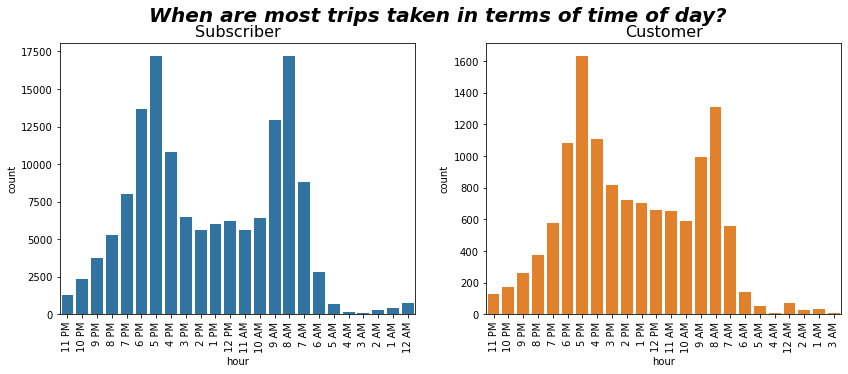

```python
colors= sns.color_palette()[0:2]

fig = plt.figure(figsize=(14,5))
plt.suptitle('When are most trips taken in terms of time of day?',style='italic',fontsize=20,fontweight='heavy')
ax = fig.add_subplot(121)
sns.countplot(x=df.query('user_type=="Subscriber"')['hour'],color=colors[0],ax=ax)
plt.title('Subscriber',fontsize=16)
plt.xticks(rotation=90)

ax = fig.add_subplot(122)
sns.countplot(x=df.query('user_type=="Customer"')['hour'],color=colors[1],ax=ax)
plt.title('Customer',fontsize=16)
plt.xticks(rotation=90);
```

- **most of trips start between 4-6 PM or 7-9 AM.**
- **trips in day have the same pattern for both costumers and subscribers.**

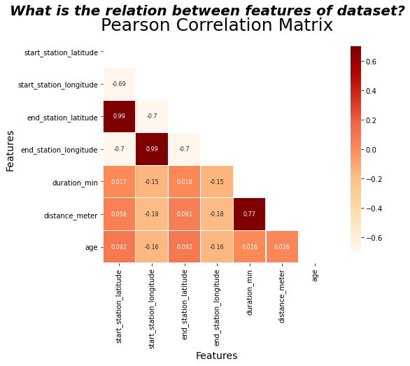

```python
#heatmap to show the correlation coeff of features.
mask = np.zeros_like(df.corr(), dtype=np.bool)
mask[np.triu_indices_from(mask)] = True

f, ax = plt.subplots(figsize=(10,6))
plt.suptitle('What is the relation between features of dataset?',fontsize=20,style='italic',fontweight='heavy')
plt.title('Pearson Correlation Matrix',fontsize=25)
sns.heatmap(df.corr(),linewidths=0.25,vmax=0.7,square=True,cmap="OrRd",
            linecolor='w',annot=True,annot_kws={"size":8},mask=mask,cbar_kws={"shrink": .9})
plt.xlabel('Features',fontsize=14)
plt.ylabel('Features',fontsize=14);
```

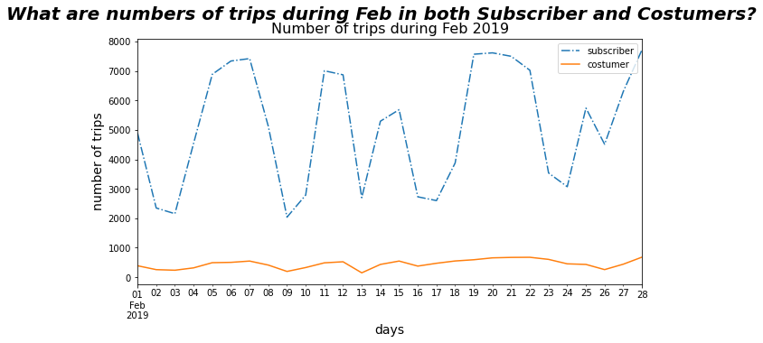

```python
fig = plt.figure(figsize=(10,5))
# resample the data in order to rearange it based on number of trips of user types.
plt.suptitle('What are numbers of trips during Feb in both Subscriber and Costumers?',fontsize=20,style='italic',fontweight='heavy')

subscriber = df.query('user_type=="Subscriber"')
subscriber.resample('D',on='start_time')['bike_id'].count().plot(ls='-.',label='subscriber')
costumer = df.query('user_type=="Customer"')
costumer.resample('D',on='start_time')['bike_id'].count().plot(label='costumer')
plt.title('Number of trips during Feb 2019',fontsize=16)
plt.xlabel('days',fontsize=14)
plt.ylabel('number of trips',fontsize=14)
plt.legend(loc = 'upper right');
```

**The above graph show the daily report of numbers of trips during Feb 2019. Subscribers graph fluctuates unlike the costumers graph which show some stability during the month.**

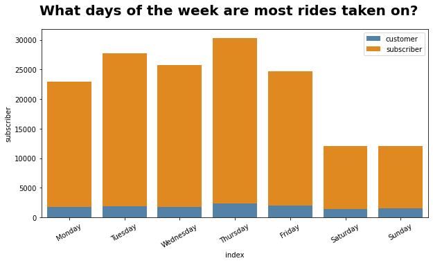

```python
days_label = ['Monday','Tuesday','Wednesday','Thursday','Friday','Saturday','Sunday']

fig = plt.figure(figsize=(10,5))
plt.suptitle('What days of the week are most rides taken on?',fontsize=20,fontweight='bold')

# Subscribers trips dring days of week.
day_subscriber = df.query('user_type=="Subscriber"')['day'].value_counts().reset_index()
day_subscriber.rename(columns={'day':'subscriber'},inplace=True)

# Customers trips dring days of week.
day_customer = df.query('user_type=="Customer"')['day'].value_counts().reset_index()
day_customer.rename(columns={'day':'customer'},inplace=True)

# join Subscribers and Customers data in one table
users = pd.merge(day_subscriber,day_customer,how='inner',on='index')
users.set_index('index',inplace=True)
users = users.reindex(days_label)

# plot the stacked bar plot of subscribers and customer data.
ax = fig.add_subplot(111)
sns.barplot(users.index,users.customer,color='steelblue',label='customer',ax=ax)
sns.barplot(users.index,users.subscriber,color='darkorange',label='subscriber',ax=ax,**{'bottom':users.customer})
plt.xticks(rotation=30)
plt.legend();
```

**numbers of costumers trips over a week is steady unlike subscribers trips which decreased significantlly during weekends.**

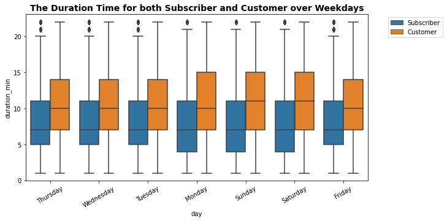

```python
fig = plt.figure(figsize=(10,5))
# boxplot of durantion of trips in both user types.
sns.boxplot(data=df,x='day',y='duration_min',hue='user_type')
plt.title('The Duration Time for both Subscriber and Customer over Weekdays',fontsize=14,fontweight='bold')
plt.xticks(rotation=30)
plt.legend( bbox_to_anchor=(1.05, 1), loc='upper left');
```

**Costumers are usually takes more time for their trips than subscribers on avrage during whole week.**

## Conclusion

> **In conclusion, based on visualization statistics; bike sharing usage among subscribers focuses on going to nearby work and return to home later. costumers usage is less directed to going to work but it is not siginficant to numbers of subscribers.**